/ home / posts

# The Gaza Conflict

& Strategic Social Dominance

An investigation of power and norms.

Author

Justin Dollman

Published

January 12, 2025

# NOTICE!

This piece is currently up as a placeholder so that links in other pieces don’t produce errors. The post will be finalized and posted after I get a couple of subsidiary-yet-somehow-prerequisite measurement posts up. Ideal world: February. Real world: probably March.

# Appendix (📉🫩🥱) aka “Descriptive Insights” (📈🫨🎰)

## Sample Selection

Unlike most studies, the self-selection of those who ended up in the Israel-Palestine study arm sheds light on the issue itself. As mentioned in the introduction, our design was to show partisans of the two sides either favorable or unfavorable information about the prospects of the side they identified with. Obviously, not everyone *is* a partisan of one of the two sides. These people can’t substantively participate in this experiment, so we wanted to detect them and have them participate in a different experiment (one where they could potentially contribute useful information). The detection of these people provides the first interesting analysis.

As a reminder, we started with 712 participants demographically representative of the US adult population.[^1] 65 members of this original sample were excluded from all analyses as they sped through the survey faster than one could have read and understood the materials, much less given them any consideration. The $712 - 65 = 647$ remaining participants make up the starting point for all the comments that follow.

<sup>1</sup> This a service CloudResearch offers. Also, it’s possible that it was actually representative of the *electorate*, a non-identical but perhaps even more relevant population.

After asking demographic questions, we asked the following question:

Recently there has been a lot of news about the conflict between Israelis and Palestinians in the Middle East. Which of the following statements best describes your feelings about the conflict?

When I think about the conflict, I tend to identify more with the Israeli side

When I think about the conflict, I tend to identify more with the Palestinian side

When I think about the conflict, I tend not to identify with either side

Of the 647 non-speeders, 162 (25%) identified with the Israeli side, 183 (28%) identified with the Palestinian side, and the remaining 302 (47%) chose the third option. Those who chose the last option then saw:

Even if you do not tend to identify with either side, would you say that you lean towards one side or the other?

I tend to lean toward the Israeli side

I tend to lean toward the Palestinian side

I do not lean toward either side

Of these, 60 (20%) indicated that they lean toward the Israeli side, while 64 (21%) leaned toward the Palestinian side, leaving 178 (59%) again choosing neither side.

All in all, the flow of participants as a minimalist pipe diagram looks as follows:

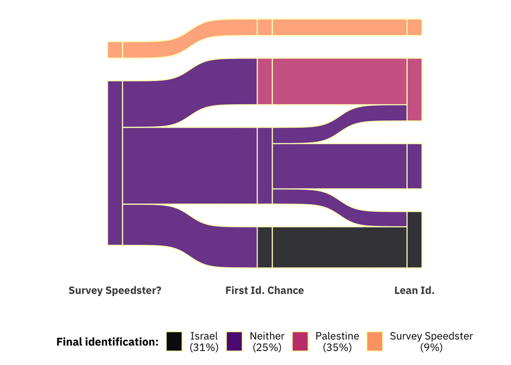

Some philistine may see this and think, ‘So what? Some people identify with one side or the other and some identify with neither. It’s life!’ But for those alive at the time, I think we remember the Gaza conflict as a subject that evoked passions, to say the least. The issue led many compatriots to change their vote, to note vote, to go out in protest, to counterprotest, etc. Among those could be considered ‘terminally online’, it would seem strange to *not* be a partisan of one of the sides. But if we leave aside the particulars of the conflict, Americans are (in)famous for not caring about foreign affairs. Maybe that’s your prior, instead.[^2]

<sup>2</sup> Savvy as you are, you consumer of stylized public opinion factoids!

But there’s another thing that would be much more surprising to a time-traveller from the recent past, regardless of their priors about American’s strength of feeling about foreign affairs: the plurality of this representative-ish sample identified with *Palestine*. Though I doubt this superiority in numbers would pass any reasonable test of statistical significance, even not being able to reject a null of equal identification would have been shocking as of just a [few](https://ropercenter.cornell.edu/blog/american-public-and-israel) [years](https://forward.com/opinion/397048/almost-everything-you-knew-about-the-polls-and-israel-is-wrong/) [ago](https://www.pewresearch.org/global/2006/07/19/the-us-publics-pro-israel-history/).

### Background Variables

To understand who identifies with which side, or at least which demographic variables are important in predicting identification, I ran a random forest model.[^3] Specifically, I predicted respondents’ “identification” category (no identification, plus ‘direct’ and ‘lean’ identification with the two sides) using (mostly) demographic variables.[^4]

<sup>3</sup> For those unfamiliar with random forests, there is an explanation forthcoming! For now just look at the colorful dots and think “machine learning is cool. The guy who made this must be really cool.”

<sup>4</sup> I’m including political interest and ideology, which aren’t demographic. In fact, they’re almost certainly endogenous! I’ll address that in the final version of the post (and I’ll also include characterological variables, Big Five and authoritarianism.)

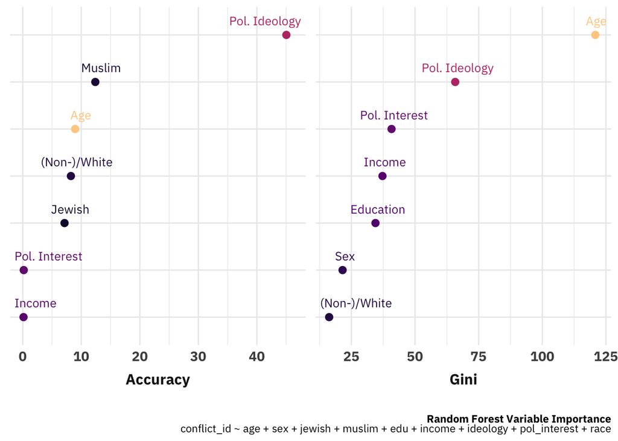

In the plot below we can see why political ideology is so important in determining (associationally) which side (if any) a person identifies with in the conflict. The majority of all types of liberals identifies with Palestine, the plurality of self-described moderates identifies with neither sid, and the majority of conservatives identifies with Israel.

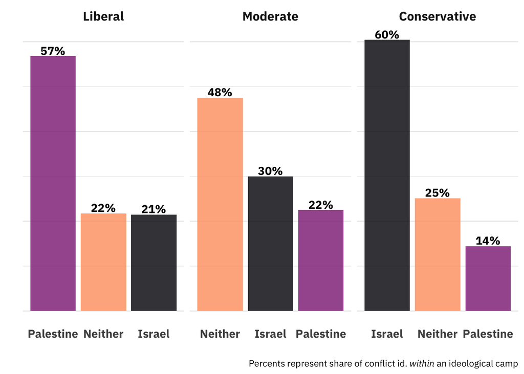

Similarly, we can see age’s importance:

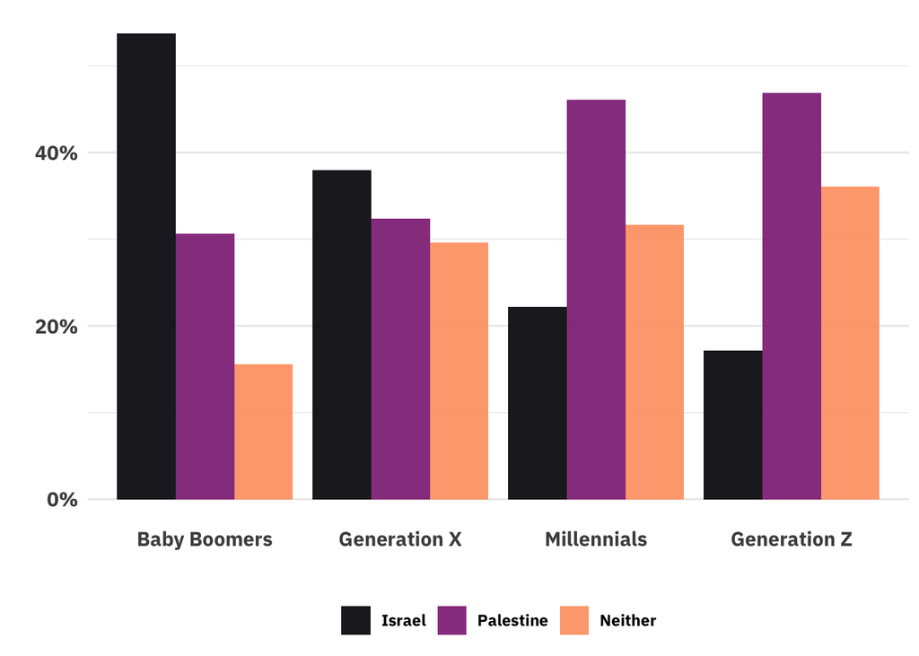

You can think of this plot as telling you, “If you meet a random person from {generation}, what is the probability that identify with/lean toward {Israel, Palestine, neither side}?” And you see extremely strong generational effects. Whereas the majority of Baby Boomers and plurality of Gen Xers identify with Israel, Israel identification is the *least* chosen option among both Millennials and Gen z. In fact, in both of those groups, identification with the Palestinian side of the conflict is about *twice* as frequent as identification with Israel.[^5]

<sup>5</sup> This is not new news. The Brookings Institute noted [it](https://www.brookings.edu/articles/the-generation-gap-in-opinions-toward-israel/) at the outset of the conflict, referencing a [Pew survey](https://www.pewresearch.org/global/2022/07/11/american-views-of-israel/) from 2022.

### Political Interest

<sup>6</sup> Political interested was measured with the question “How interested are you in politics?” to which people could choose from the options, not at all interested, slightly interested, somewhat interested, very interested. I should mention that it’s very important to refer to political interest measured this way “*self-reported* political interest” because political interest is like news consumption and voting in that all three conform to House MD’s maxim, “Everyone lies.”

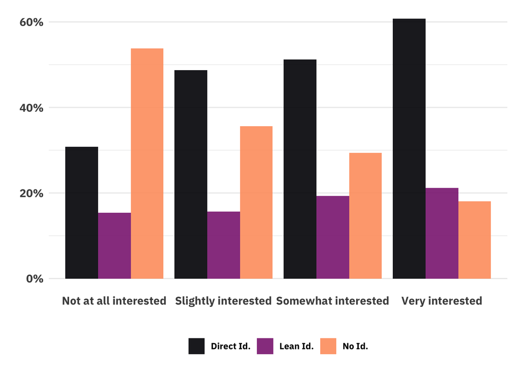